# Stat258 Group1 Presentation - Dallas Animal Shelter

December 3, 2018

## Project Description

For our group assignment, we have chose to look at a data set from an Animal Shelter in Dallas, TX. Animal shelters help animals find new homes and maintain a safe city. We believe this data set can be used to help this shelter save money and operate more efficiently. In addition, this data set can be used in various ways such as marketing, keeping appropriate inventory of pet supplies on hand, and staffing necessary resources at certain times.

The Dallas Animal Shelter data set can be found on the [TidyTuesday](https://github.com/rfordatascience/tidytuesday) project website at the following link: week18_dallas_animals.xlsx

## Outline

This presentation is meant for discussion topics. Anlayis of the graphs will be brief. Further analysis can be found in the report to come.

- Packages Used in Analysis
- Brief Description of the Dallas Animal Shelter Data
- Description on Manipulations to Data
- Dimensions of Data
- Intake Analysis
- Time at Shelter Analysis
- Outcome Analysis

## Packages Used

- `readxl` - to read in excel files.
- `scales` - for adjusting graphics legends and axes.
- `lubridate` - fast and user friendly way to work with dates.
- `rvest` - for scraping information off of the web.
- `RColorBrewer` - for changing graph colors
- `tidyverse` - a collection of packages to manipulate and graph data.

## The Data

Each data point represents a different animal that entered the shelter identified by an `andimal_id`. Each observation contains what the `intake_type` was and what the `outcome_type` was and dates of these events. In addition, there is information about the type and breed of the animal and what condition the animal was in at the time of intake and at the time of the outcome.

## Data Manipulations

- Added `intake_day` and `outcome_day` which represents the day of the week when the intake or outcome happened, respectively
- Added `total_time` which represents the number or days of the animal was at the shelter.
- Lumped the 20% least common types of dog breeds brought into the Dallas Animal Shelter as `OTHER`.

## Data Dimensions

```
##   numb_rows numb_col
## 1     34819       26
```

```
##  [1] "animal_id"              "animal_type"
##  [3] "animal_breed"           "kennel_number"
##  [5] "council_district"       "intake_type"
##  [7] "intake_subtype"         "reason"
##  [9] "staff_id"               "intake_date"
## [11] "intake_time"            "due_out"
## [13] "intake_condition"       "hold_request"
## [15] "outcome_type"           "outcome_date"
## [17] "outcome_time"           "outcome_condition"
## [19] "animal_origin"          "additional_information"
## [21] "month"                  "year"
## [23] "intake_day"             "outcome_day"
## [25] "total_time"             "new_breed"
```

## Intake Analysis

### Time Series

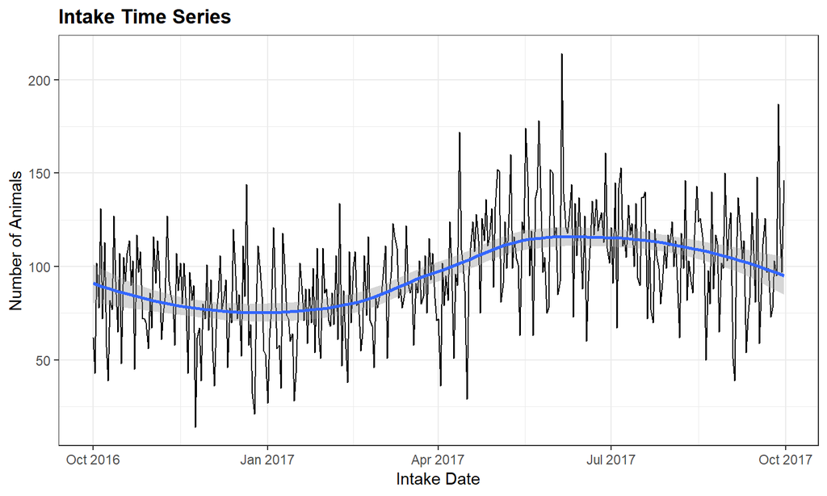

## Intake Analysis

### Time Series (cont'd)

From this graph we can see we have one years worth data from the Dallas Animal Shelter. We see that the smoothing line dips in the winter months and then spikes in the spring and summer months. However, one years worth of data is not really sufficient for identifying seasonality.

## Intake Analysis

### Intake Types

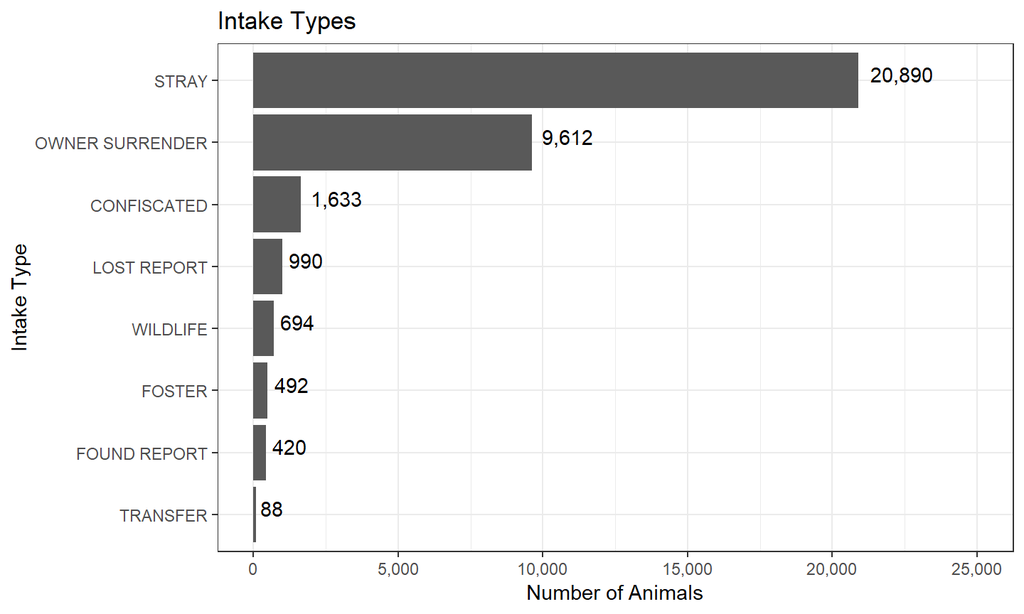

## Intake Analysis

### Top Intakes Types by Day

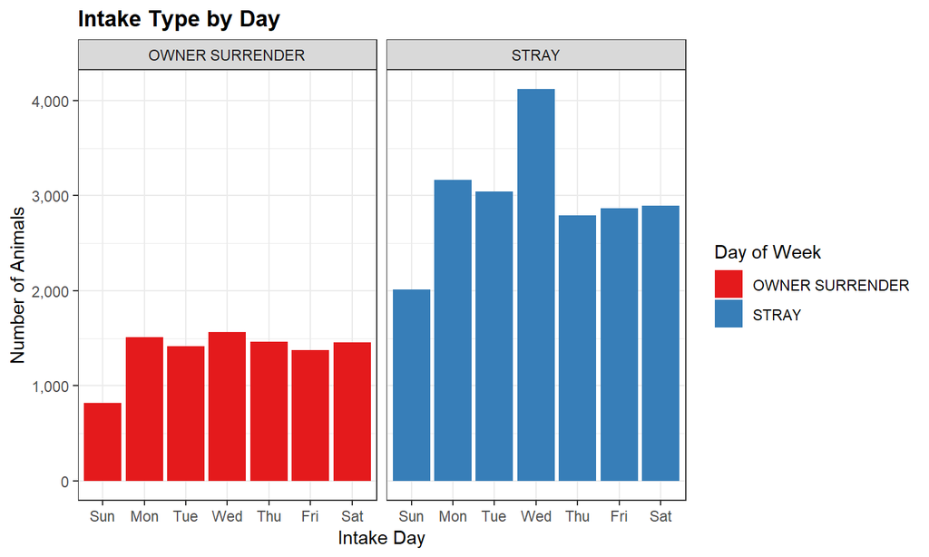

## Intake Analysis

### Animal Types

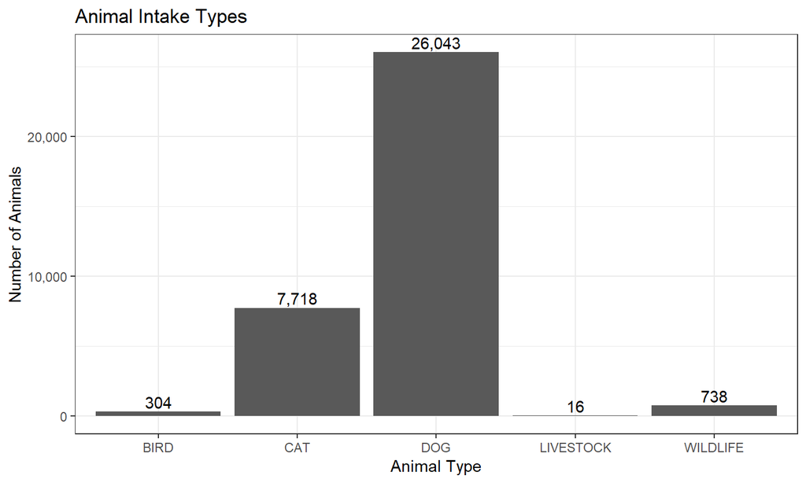

## Intake Analysis

### Dogs

As expected, there are way more dogs than anything else. Because of the large percentage of dogs compared to every other animal type, it will be worth taking a closer look at dogs specifically. As mentioned before, because there are so many dog breed types, we lumped the 20% least common types of dog breeds brought into the Dallas Animal Shelter as `OTHER`.

## Intake Analysis

### Dog Breeds

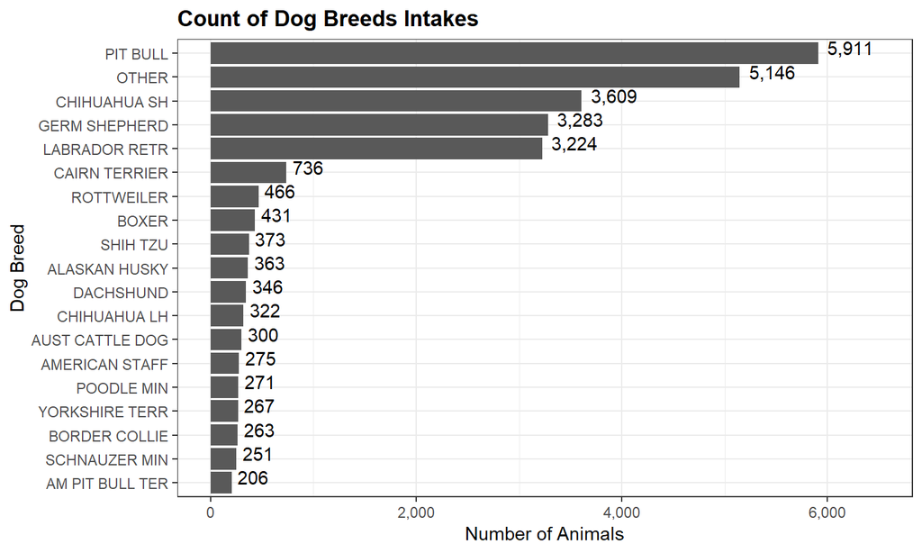

## Intake Analysis

### Dog Breed Intake Type

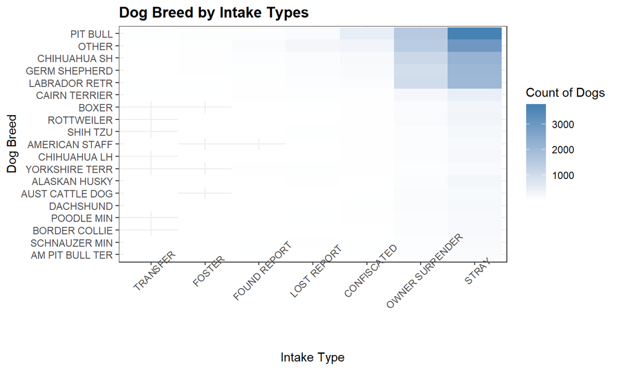

## Time at Dallas Animal Shelter

The average amount of time an animal spends at the Dallas Animal Shelter = 6.27 Days

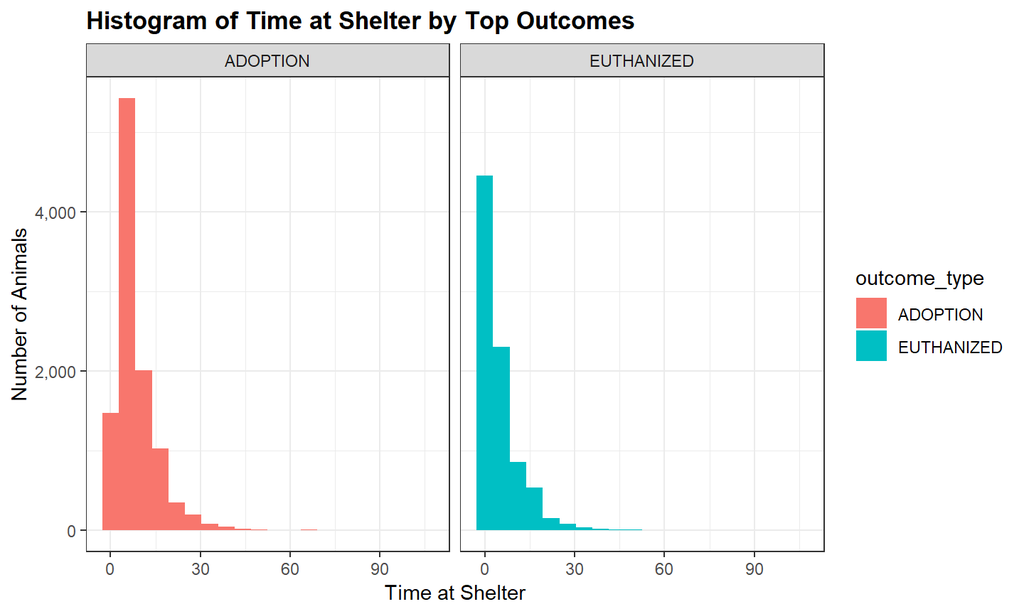

## Outcome Analysis

### Time Series

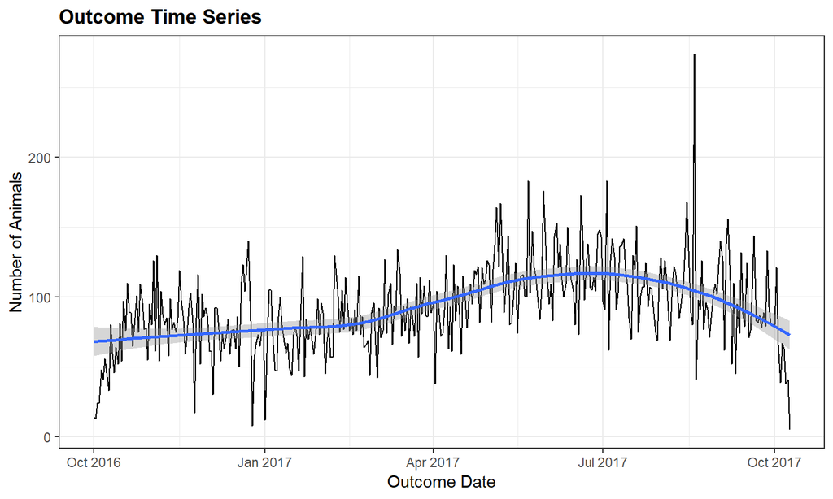

## Outcome Analysis

### Dog Breed Outcome Type

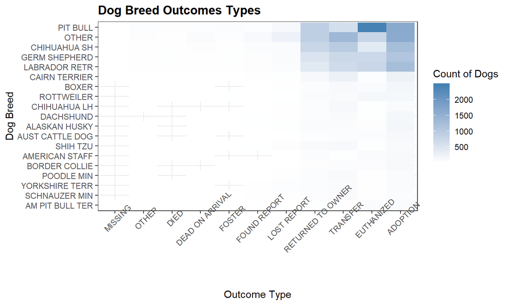

## Outcome Analysis

### Dog Breed Adoption Week Days

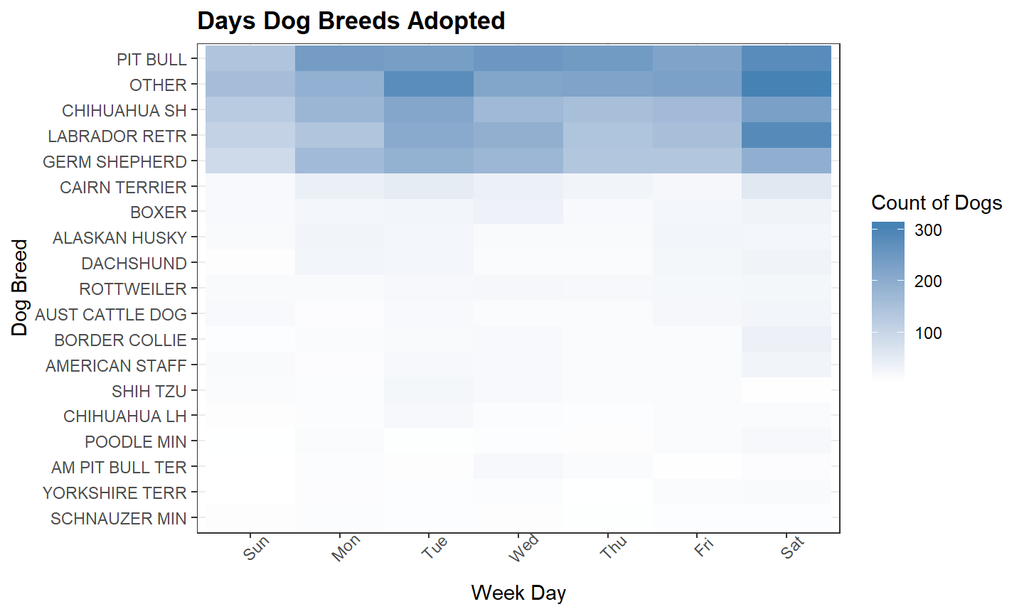

## Outcome Analysis

### Adoptions by Day

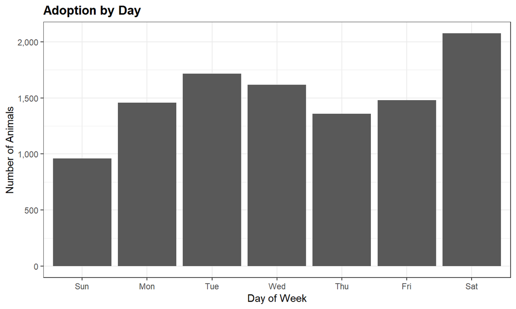

## Outcome Analysis

### Holidays

Here we will read in a federal holiday data set from [Kaggle](https://www.kaggle.com/gsnehaa21/federal-holidays-usa-19662020) to see if adoptions spike around holidays

## Outcome Analysis

### Holidays Time Series

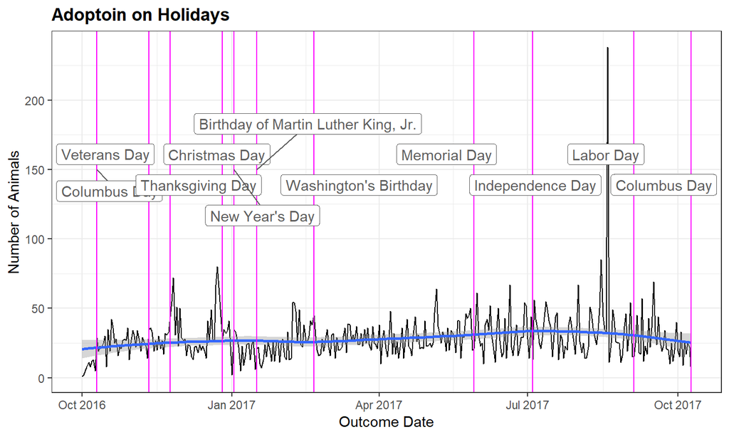